# Case Study: How does a bike-share navigate speedy success?

Błażej

2025-10-24

# Introduction

This is a case study of a fictional company, Cyclistic, for Google Data Analytics course on Coursera. The study will follow the steps of data analysis process, which are **Ask**, **Prepare**, **Process**, **Analyze**, **Share** and **Act**. All data included in this study is available on a separate PDF file, including the introduction to the entire scenario, as well as characters and teams that will be mentioned later on.

## Ask phase

**Cyclistic** is a growing Chicago bike-share program, with a fleet of 5824 bicycles and 692 stations. Its marketing strategy previously focused on broad awareness and flexible pricing plans: singe-ride passes, full-day passes, and annual memberships. Customers purchasing services using first two pricing plans are referred to as *casual riders*, while the customers that purchase annual memberships are *Cyclistic members*.

To maximize future growth, the company believes converting casual riders into members is the optimal strategy, as annual members are significantly more profitable. Therefore, the core business task for this study is to understand: **How do annual members and casual riders use Cyclistic bikes differently?**

## Prepare phase

This analysis is based on [Divvy 2019 Q1](https://docs.google.com/spreadsheets/d/1uCTsHlZLm4L7-ueaSLwDg0ut3BP_V4mKDo2IMpaXrk4/template/preview?resourcekey=0-dQAUjAu2UUCsLEQQt20PDA#gid=1797029090) and [2020 Q1](https://docs.google.com/spreadsheets/d/179QVLO_yu5BJEKFVZShsKag74ZaUYIF6FevLYzs3hRc/template/preview#gid=640449855) historical trip data, provided by Motivate International Inc.. For purpose of this case study we consider them to be accurate and relevant to Cyclistic’s business questions. The data used is made available for use by following [license](https://www.divvybikes.com/data-license-agreement). These datasets contain data on all bike rides in first quarter of 2019 and 2020.

We will focus on key variables related to trip usage - start and end times of each ride, user type and the length of the ride (this one will be calculated). The datasets will be formatted consistently, resulting in five core columns for further analysis - **start**, **end times**, **user type**, **duration**, and **day of the week** - some of which will be calculated later on

## Process phase

The processing stage, handled in a separate R script, involves cleaning and transforming the data. This includes **removing missing values and duplicates**, creating **trip duration** (in minutes) column and calculating the **day of the week**. Finally, outliers will be removed, specifically trips shorter than 1 minute and longer than 3 weeks, and the two datasets will be merged into one.

## Analyze phase

```r
MeanDuration
```

```
## # A tibble: 2 × 2
##   usertype MeanDuration
##   <chr>           <dbl>
## 1 casual           59.6
## 2 member           12.4
```

```r
RideCount
```

```
## # A tibble: 2 × 4
##   usertype      n   perc labels
##   <chr>     <int>  <dbl> <chr>
## 1 casual    67621 0.0863 9%
## 2 member   716210 0.914  91%
```

## Share phase

To show the key differences we can take a look at graphs about both user groups:

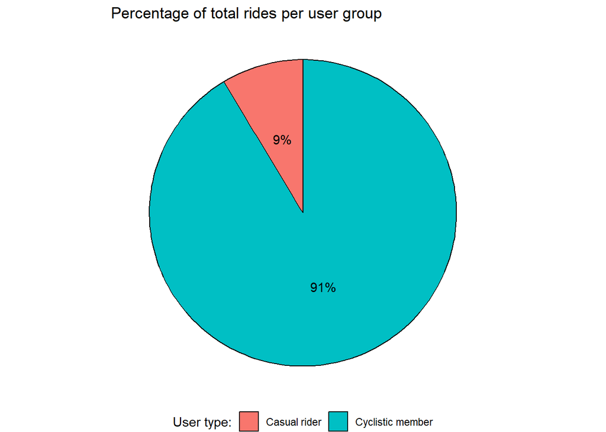

This chart shows the difference between the amount of rides between both groups - it appears that **Cyclistic members account for over 90% of all rides**, making this the largest group. Even though they ride much more often, we can also take a look at the difference in average trip time:

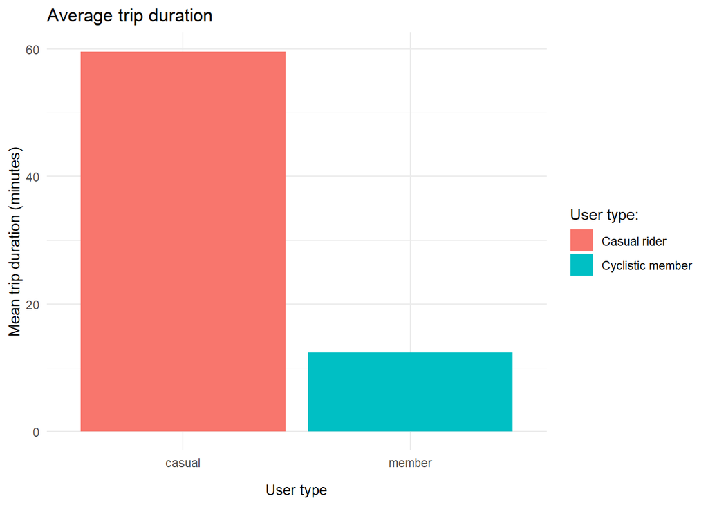

This chart shows that even though they represent only 9% of all rides, the **casual riders usual trip duration is close to an hour**, while the **members prefer shorter rides - about 12 minutes**. Lastly, let’s take a look at the weekly distribution of these rides:

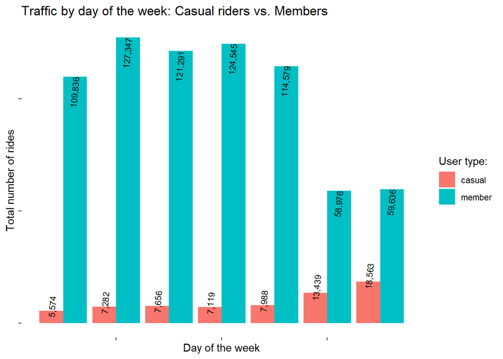

This way we can see another difference between both groups - **casual riders make their trips more often on weekends**, while **members ride considerably more often during business days**.

## Act phase

Suggested next step are tailoring weekend offers to casual riders. Focus membership messaging on commuting and convenience to align with frequent weekday usage pattern. Another recommendations would be implementing a conversion possibility based on trip-lengths.